# GAMLSS and quantile GAM modelling

Matteo Fasiolo

June 26 2018

N.B. GAMLSS models cannot be fitted using `bam` or `bamV`. Big Data methods for GAMLSS models in `mgcv` are still under development.

# Grip strength modelling

We consider a simple data set containing data on grip strength (HG) vs age:

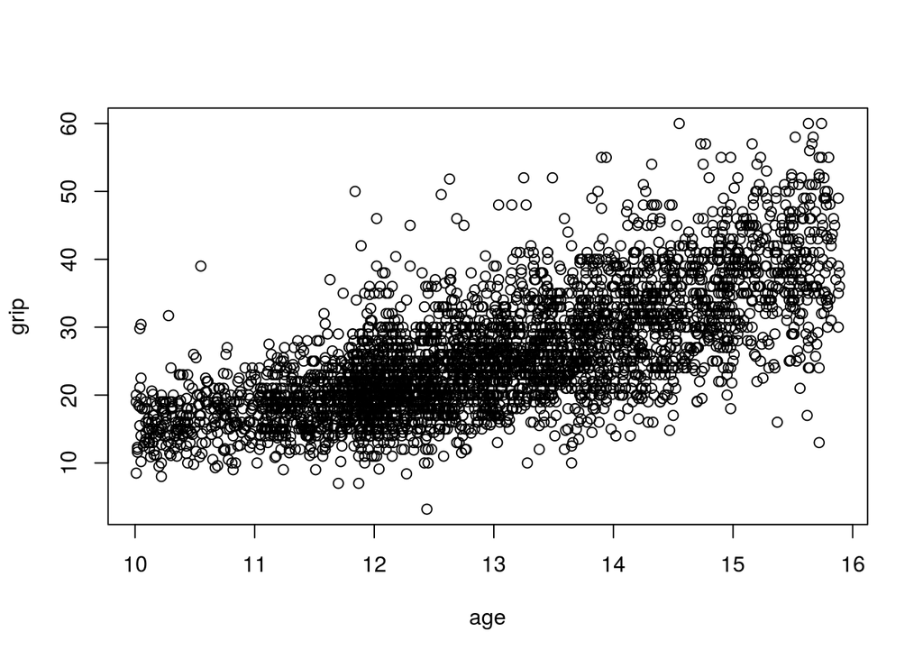

```r
library(mgcViz)
library(gamlss.data)
data(grip)

plot(grip ~ age, data = grip)
```

We fit a standard Gaussian GAM, and we check the residuals standard deviation of a grid of values along `age`:

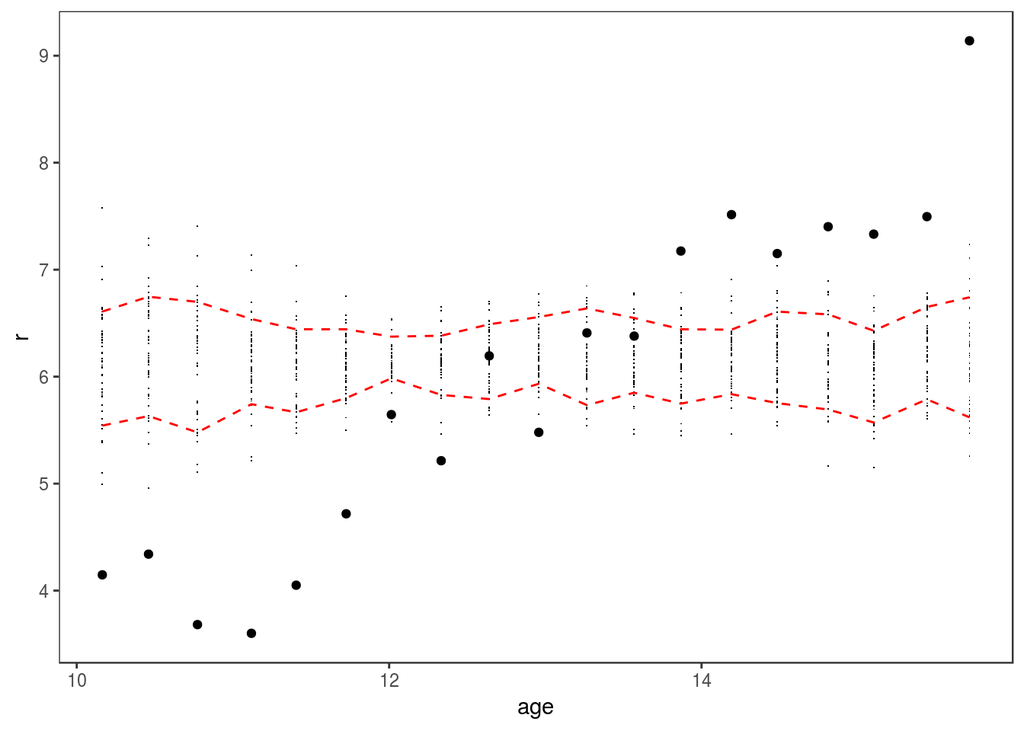

```r
fit1 <- gamV(grip ~ s(age),
             data = grip,
             aViz = list(nsim = 50))

check1D(fit1, "age") + l_gridCheck1D( sd ) # <- notice that we are looks at stan dev
```

The variance is clearly increasing with `age`. With take this into account using a `gaulss` model:

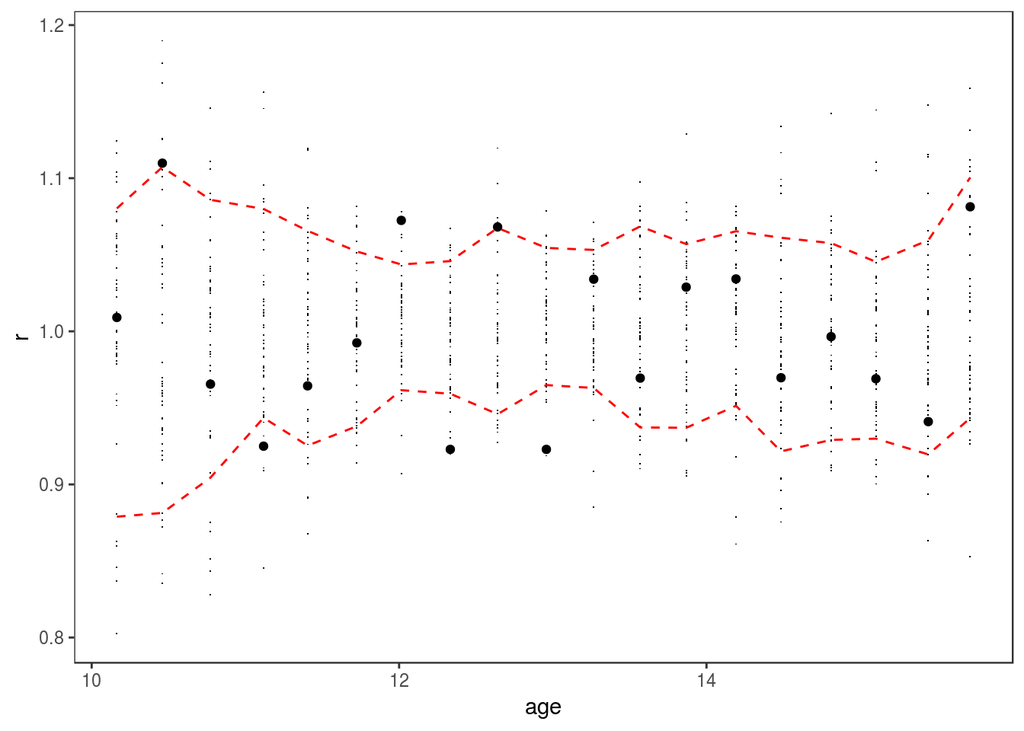

```r
fit2 <- gamV(list(grip ~ s(age), ~ s(age)),
             data = grip,
             family = gaulss,
             aViz = list(nsim = 50))

check1D(fit2, "age") + l_gridCheck1D( sd ) # <- notice that we are looks at stan dev
```

The residual check now looks ok. These are the estimated mean and stand. dev. effects:

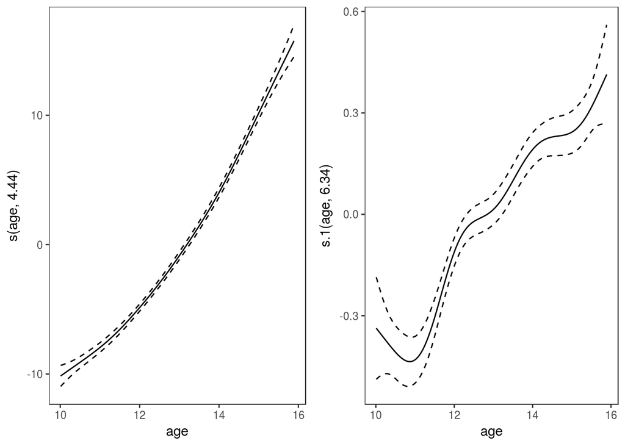

```r
print(plot(fit2), page = 1)
```

We can know check whether the residual skewness (asymmetry) changes with age:

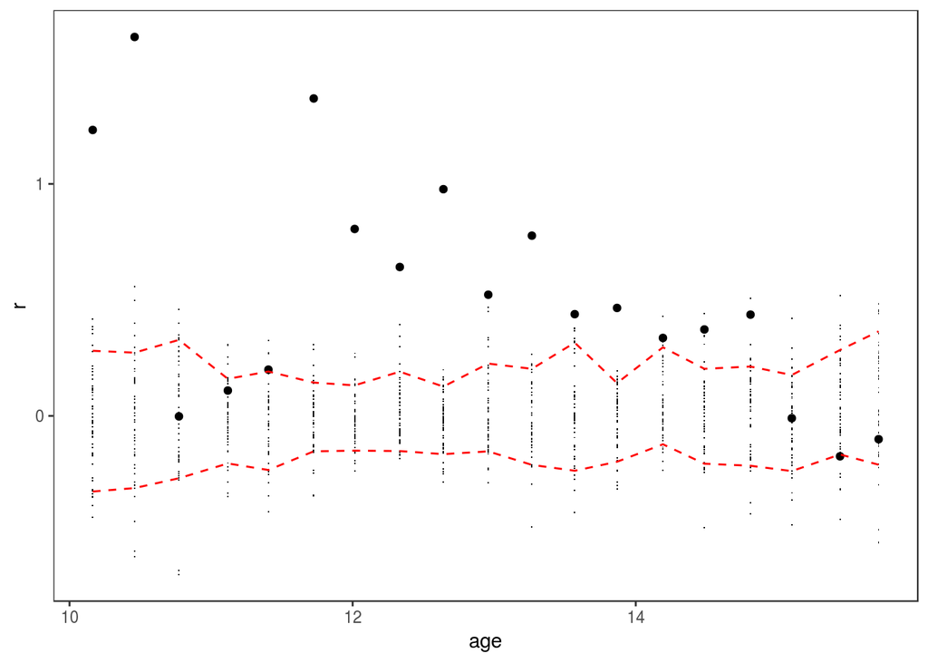

```r
library(e1071)
check1D(fit2, "age") + l_gridCheck1D( skewness )
```

It seems that the residuals are quite skewed to the right. We allow for skewness by adopting a `shash` model:

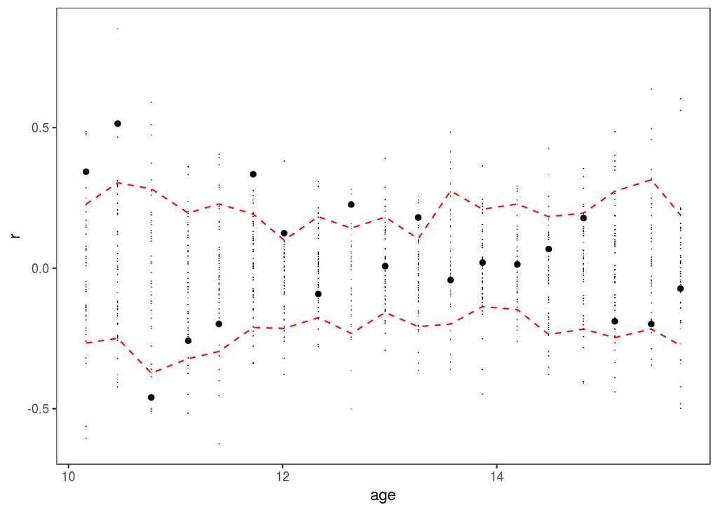

```r
library(mgcFam)
fit3 <- gamV(list(grip ~ s(age), # location
                  ~ s(age),      # scale (variance)
                  ~ s(age),      # skewness (asymmetry)
                  ~ 1),          # kurtosis (tail behaviour)
             data = grip,
             family = shash,
             aViz = list(nsim = 50))

check1D(fit3, "age") + l_gridCheck1D( skewness )
```

The skewness seems to be better modelled now, and we achieve lower AIC:

```r
AIC(fit1, fit2, fit3)
```

```
##             df      AIC
## fit1  6.603372 24369.57
## fit2 13.896755 24049.30
## fit3 15.237918 23873.78
```

The next step is to have a look at residual kurtosis (tail behaviour), this could be done by:

```r
check1D(fit3, "age") + l_gridCheck1D( kurtosis )
```

but we leave it for next time.

# More complex checks

An alternative conditional residual check is provided by `l_densCheck` layer. This compares the empirical and the theoretical (model based) residuals distribution. It generates a heat-map of:
$$\delta(x, r) = \verb|dFun|\{\hat{p}(r|x) - \phi(r|x) \},$$
where

- $\hat{p}(r|x)$ is an estimate of the conditional distribution of the residuals $r$;
- $\phi(r|x)$ is theoretical distribution (currently only $N(0, 1)$);
- `dFun` is a distance function. By default: `dFun <- function(emp, th) abs(sqrt(em)-sqrt(th))^(1/3)|.`

`l_densCheck` is useful for identifying residual anomalies, varying variance, skewness etc. Usage:

```r
check1D(fit1, "age") + l_densCheck(  )
```

Here are some examples on how to interpret such plots:

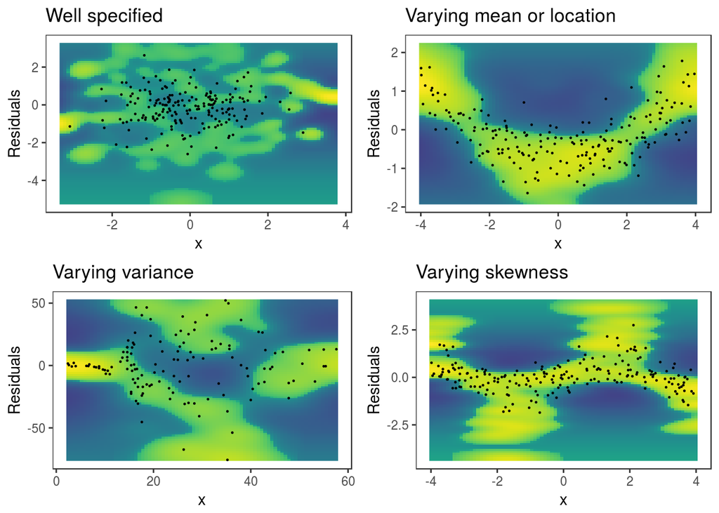

# Quantile modelling: income vs age

The `qgam` R package offers methods for fitting additive quantile regression models based on splines, using the methods described in [Fasiolo et al., 2017](https://arxiv.org/abs/1707.03307). It is useful to use `qgam` together with `mgcViz`, which extends the basic visualizations provided by `mgcv`.

The main fitting functions are:

- `qgam()` fits an additive quantile regression model to a single quantile. Very similar to `mgcv::gam()`. It returns an object of class `qgam`.
- `mqgam()` fits the same additive quantile regression model to several quantiles. It is more efficient that calling `qgam()` several times, especially in terms of memory usage.
- `qgamV()` and `mqgamV()` are two convenient wrappers that fit quantile GAMs and return `gamViz` objects, for which `mgcViz` provides lots of visualizations.

We start by considering a small data set and fitting a median model:

```r
library(mgcViz)
library(SemiPar)
data(age.income)
age.income$income <- exp(age.income$log.income)

fitQ <- qgamV(income ~ s(age), data = age.income, qu = 0.5)
```

```
## Estimating learning rate. Each dot corresponds to a loss evaluation.
## qu = 0.5.........done
```

Then we predict and plot:

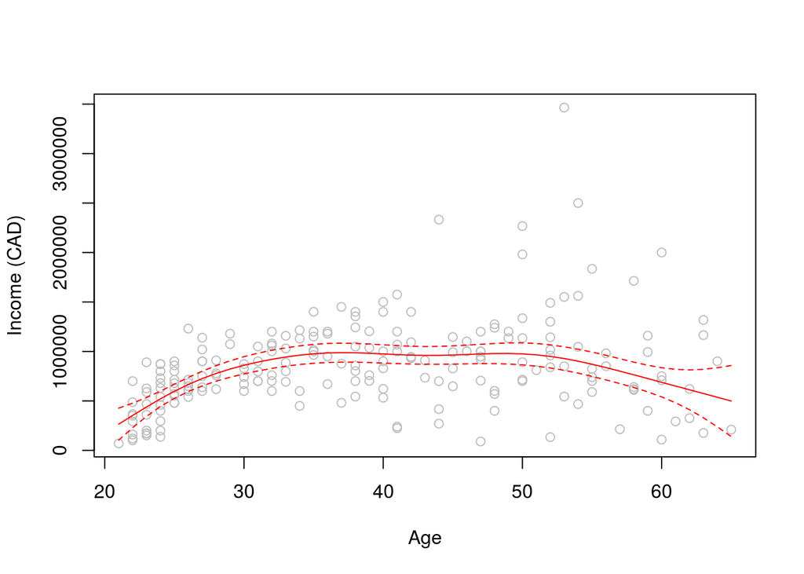

```r
ft <-  predict(fitQ, se = TRUE)

ord <- order(age.income$age)
plot(age.income$age, age.income$income, xlab = "Age",
     ylab = "Income (CAD)", col = "grey")
lines(age.income$age[ord], ft$fit[ord], col = 2)
lines(age.income$age[ord], (ft$fit + 2 * ft$se.fit)[ord], col = 2, lty = 2)
lines(age.income$age[ord], (ft$fit - 2 * ft$se.fit)[ord], col = 2, lty = 2)
```

Now we fit multiple quantile at once, then we predict and plot the fit:

```r
fitQ <- mqgamV(income ~ s(age), data = age.income, qu = c(0.1, 0.25, 0.5, 0.75, 0.9))
```

```
## Estimating learning rate. Each dot corresponds to a loss evaluation.
## qu = 0.5.........done
## qu = 0.25........done
## qu = 0.75...........done
## qu = 0.1.........done
## qu = 0.9.....................done
```

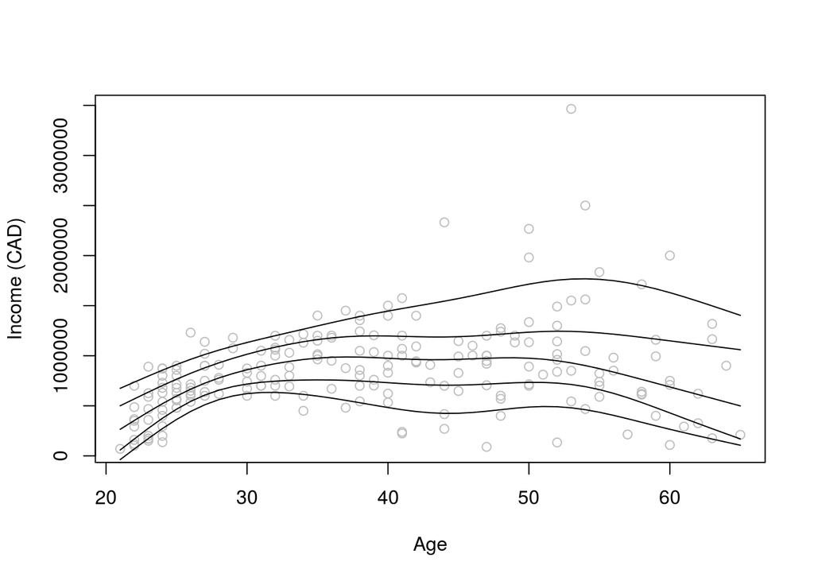

```r
plot(age.income$age, age.income$income, xlab = "Age", ylab = "Income (CAD)", col = "grey")

for(ii in 1:5){
  ft <-  predict(fitQ[[ii]], se = TRUE)
  lines(age.income$age[ord], ft$fit[ord], col = 1)
}
```

The output of `mqgamV` is a list of QGAM models, you can handle each of them as usual:

```r
summary(fitQ[[1]])
```

```
##
## Family: elf
## Link function: identity
##
## Formula:
## income ~ s(age)
##
## Parametric coefficients:
##             Estimate Std. Error z value Pr(>|z|)
## (Intercept)   430445      28337   15.19   <2e-16 ***
## ---
## Signif. codes:  0 '***' 0.001 '**' 0.01 '*' 0.05 '.' 0.1 ' ' 1
##
## Approximate significance of smooth terms:
##          edf Ref.df Chi.sq  p-value
## s(age) 4.964  5.997  68.32 9.09e-13 ***
## ---
## Signif. codes:  0 '***' 0.001 '**' 0.01 '*' 0.05 '.' 0.1 ' ' 1
##
## R-sq.(adj) =  0.116   Deviance explained = 71.9%
## -REML = 2943.4  Scale est. = 1         n = 205
```

# Rainfall modelling in Parana state of Brasil

Here we are going to model weekly rainfall (mm/week) from over 600 weather station in the Parana state of Brazil. The data comes comes from the `INLA` R package. The meaning of most variables should be evident.

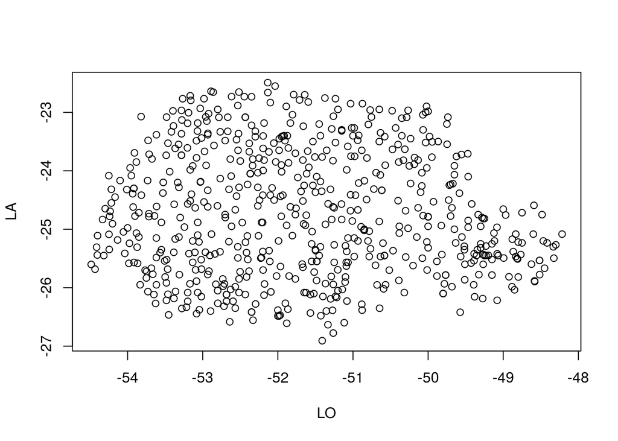

```r
library(mgcViz)
load("exercises/data/parana.rda")

plot(parana[parana$TIME==1, ]$LO, parana[parana$TIME==1, ]$LA, xlab = "LO", ylab = "LA")
```

We fit a median quantile GAM with an isotropic effect for longitude and latitude, a cyclic effect for the time of the year and smooth effects for distance from the sea and elevation:

```r
fit <- qgamV(PREC ~ s(LO, LA, k = 25) + s(seaDist) + s(TIME, bs = "cc") + s(EL),
             data = parana,
             qu = 0.5)
```

```
## Estimating learning rate. Each dot corresponds to a loss evaluation.
## qu = 0.5..............done
```

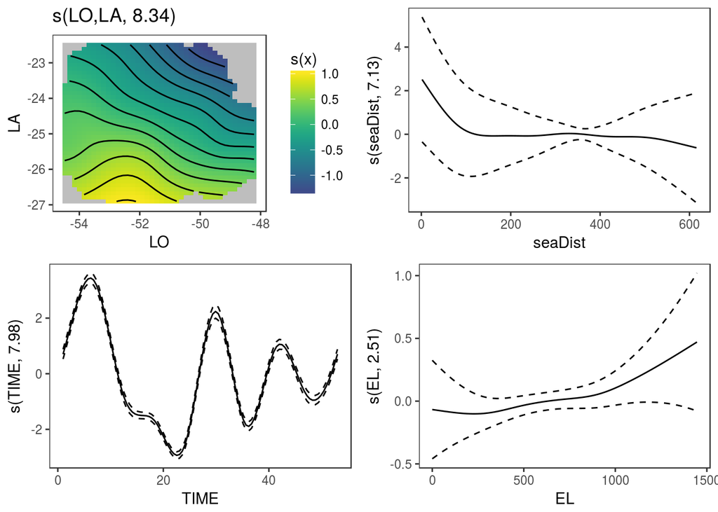

```r
print(plot(fit), pages = 1)
```

We can of course fit this model to several quantiles:

```r
fitM <- mqgamV(PREC ~ s(LO, LA, k = 25) + s(seaDist) + s(TIME, bs = "cc") + s(EL),
               data = parana,
               qu = seq(0.1, 0.9, length.out = 5),
               err = 0.1)
```

```
## Estimating learning rate. Each dot corresponds to a loss evaluation.
## qu = 0.5.............done
## qu = 0.3.................done
## qu = 0.7...................done
## qu = 0.1.......................done
## qu = 0.9.............done
```

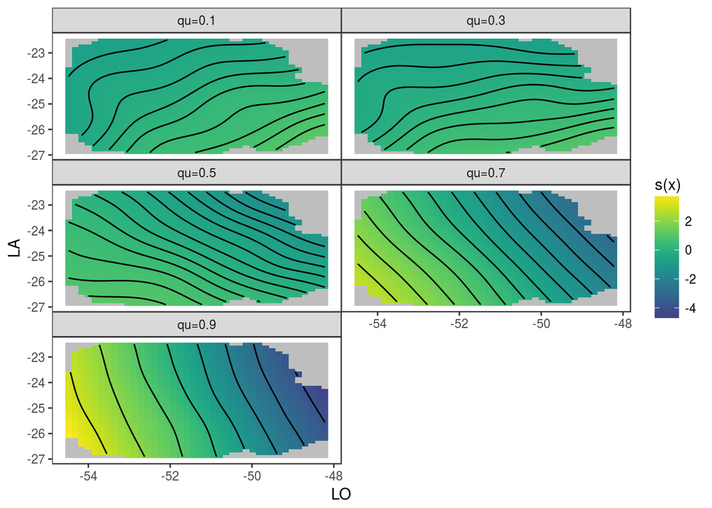

```r
plot(fitM, select = 1)
```

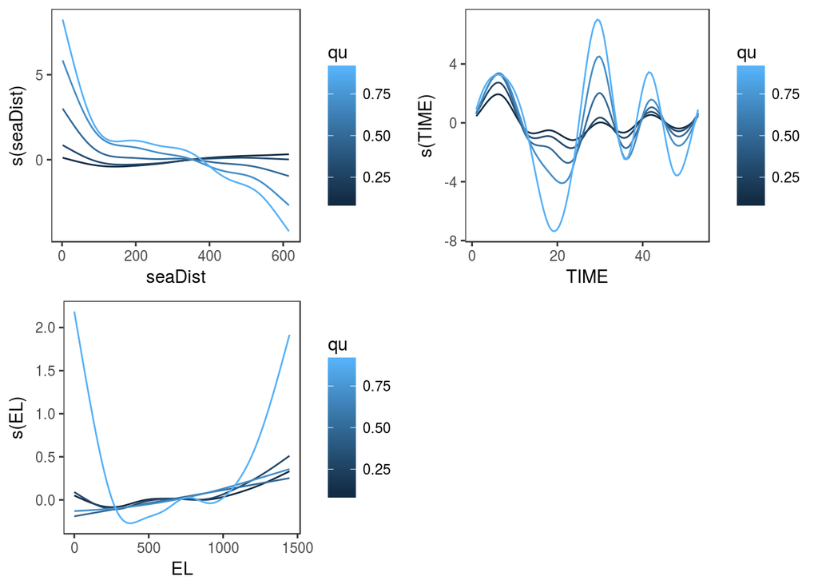

```r
print(plot(fitM, select = 2:4), pages = 1)
```

```r
plotRGL(sm(fitM[[5]], 1)) # This will not appear in the html file
```

We might also wonder whether the spatial effect changes with time. To verify this here we construct a tensor product smooth between the 2D thin-plate-spline spatial effect and the cyclical effect of time. We simplify the model by removing the effect of `seaDist`.

```r
fit4 <- qgamV(PREC ~ te(LO, LA, TIME, d = c(2, 1), k = c(20, 10), bs = c("tp", "cc")) + s(EL),
              data = parana,
              qu = 0.9,
              err = 0.1)
```

```
## Estimating learning rate. Each dot corresponds to a loss evaluation.
## qu = 0.9..........done
```

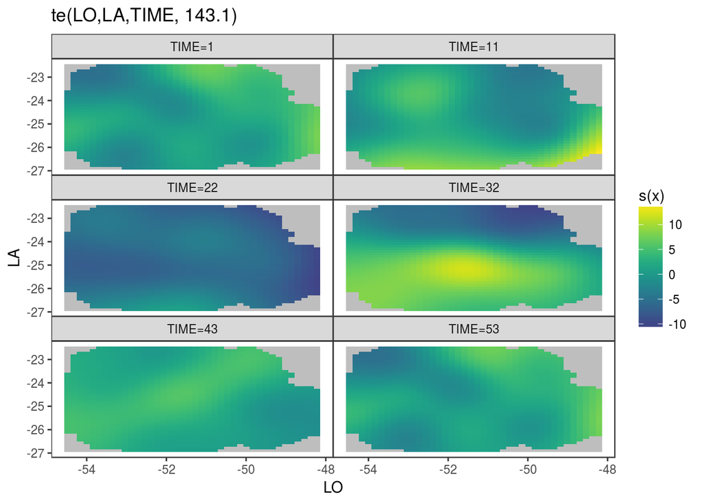

```r
plotSlice(sm(fit4, 1),
          fix = list("TIME" = round(seq(1, 53, length.out = 6)))) + l_fitRaster()
```

You can plot any slice in 3D by doing:

```r
plotRGL(sm(fit4, 1), fix = c("TIME" = 11)) # This will not appear in the html file
```

# References

Wood S. N. (2017) Generalized additive models: an introduction with R. Second edition. Chapman and Hall/CRC, 2017.